# Time Series: A First Course with Bootstrap Starter

# Lesson 12-1: Sampling Distributions

- In time series (and statistics in general) we want to know the uncertainty in our estimates.
- First we study the sampling distributions of statistics.

## Remark 12.1.4. Improving on the Normal Approximation

- A confidence interval for the mean requires us to know the *long-run variance*,
  $$\sigma^2_{\infty} = \sum_{h = - \infty}^{\infty} \gamma (h).$$
- The $95 \%$ confidence interval based on the sample mean and the normal approximation is
  $$\overline{X}_n \pm 1.96 \sqrt{\frac{ \widehat{\sigma_{\infty}^2} }{n}
  }.$$
- There are some issues with the accuracy of this interval:
1. The accuracy of the normal approximation in finite sample (non-normality of marginal distribution).
2. Serial correlation in the time series, since
   $$\mbox{Var} [ \sqrt{n} \overline{X}_n ] \rightarrow \sigma^2_{\infty},$$
   and the convergence can be slow.
3. Estimation of $\sigma^2_{\infty}$ by some estimator $\widehat{\sigma^2_{\infty}}$ (this could be constructed from sample autocovariances).
- So we might consider directly approximating the distribution of $\overline{X}_n$ via *resampling* from $\{ X_t \}$. This is the idea of the *bootstrap*.

## Example 12.1.6. Mean of a Gaussian AR(1).

- Suppose that $\{ X_t \}$ is a stationary Gaussian AR(1) process, with parameter $\phi_1$.
- So the spectral density is $f(\lambda) = \sigma^2 \, {| 1 - \phi_1 e^{-i \lambda} |}^{-2}$.
- The asymptotic variance of $\sqrt{n} \overline{X}$ is the long-run variance: $f(0) = \sigma^2 / {(1 - \phi_1)}^2$.
- The actual variance of $\sqrt{n} \overline{X}$ is
  $$\gamma (0) + 2 \sum_{h=1}^{n-1} (1 - h/n) \gamma (h)
  = \frac{ \sigma^2 }{ 1 - \phi_1^2 } \,
  \left( 1 + \frac{2 \phi_1}{1 - \phi_1} \,
  \left[ (1 - \phi_1^n ) - \frac{ 1 - \phi_1^n (1 + n (1 - \phi_1) ) }{ n
  (1 - \phi_1) }
  \right] \right)$$
- For $\phi_1 > 0$, this quantity is smaller than the long-run variance.
- We illustrate for $\phi_1 = .9$ and $\sigma = 1$, so that $f(0) = 100$.

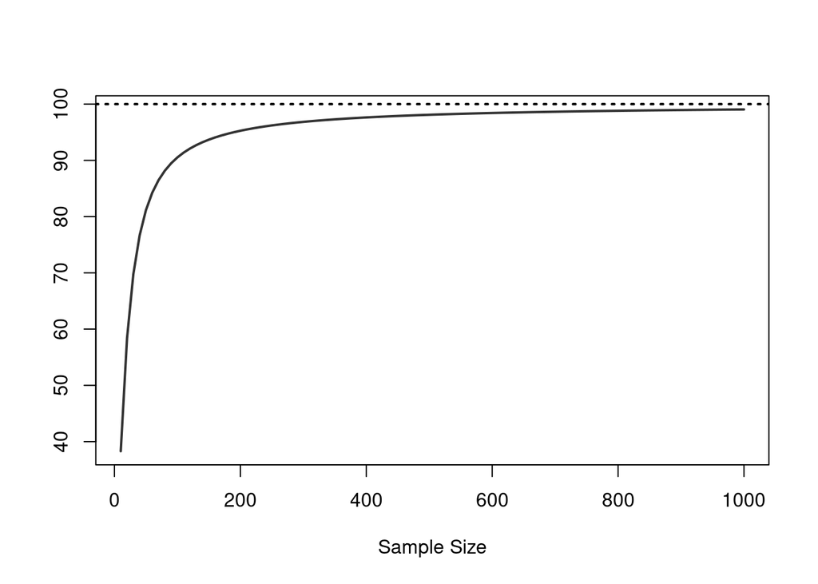

```r
phi <- .9
n <- seq(10,1000,10)

longrun.var <- (1-phi^2)^(-1)*(1 + 2*phi*(1-phi)^(-1)*
    ((1-phi^n) - (1-phi^n*(1+n*(1-phi)))*(n*(1-phi))^(-1)))
longrun.var <- ts(longrun.var,start=10,frequency=.10)
plot(longrun.var,xlab="Sample Size",ylab="",lwd=2,col=grey(.2))
abline(h=1/(1-phi)^2,lty=3,lwd=2)
```

- Thus, using $f(0)$ instead of the true sampling variance will overestimate when $n$ is small.